# **Addition Insights - Companies to Watch Newsletter**

August 19, 2021

[figure not shown]

See below an algorithmically curated selection of international publicly traded technology companies demonstrating quantifiable momentum via third-party metrics.

## **Scout24**

**Company Sector:** Marketplace, Automotive, Real Estate  
**Headquarters:** Munich  
**# of Employees:** 1,383  
**Website:** https://scout24.com/  
**Description:** Scout24 operates digital marketplaces in the real estate & automotive sectors.  
**Market Cap (USD)** $6.8B

### **Trends**

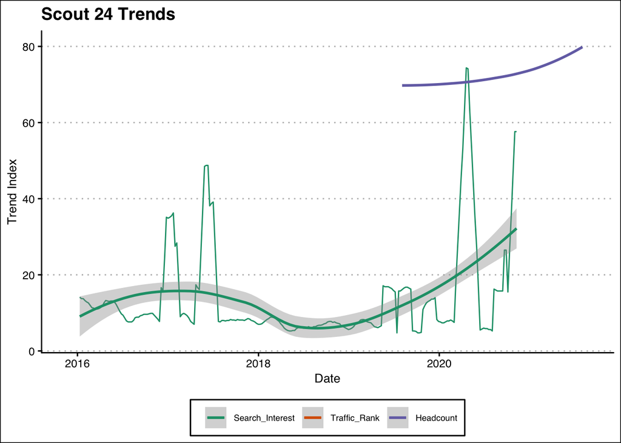

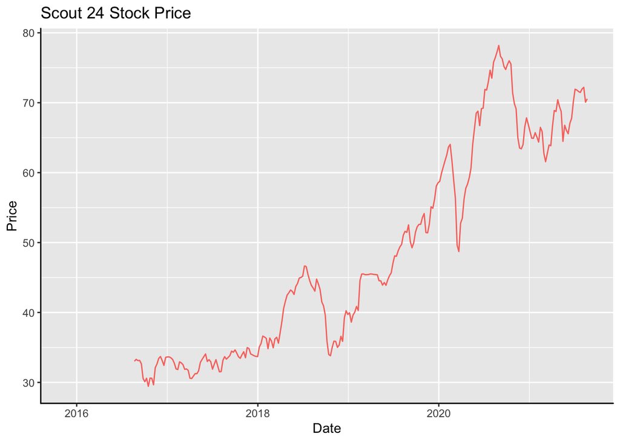

## **Nice Ltd**

**Company Sector:** Security, Automation, Data Services  
**Headquarters:** Tel Aviv  
**# of Employees:** 5,717  
**Website:** https://nice.com/  
**Description:** NICE is the worldwide leading provider of both cloud and on-premises enterprise software solutions that empower organizations to make smarter decisions based on advanced analytics of structured and unstructured data. **Market Cap (USD)** $17B

### **Trends**

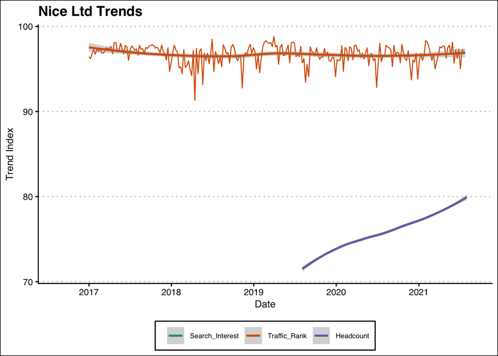

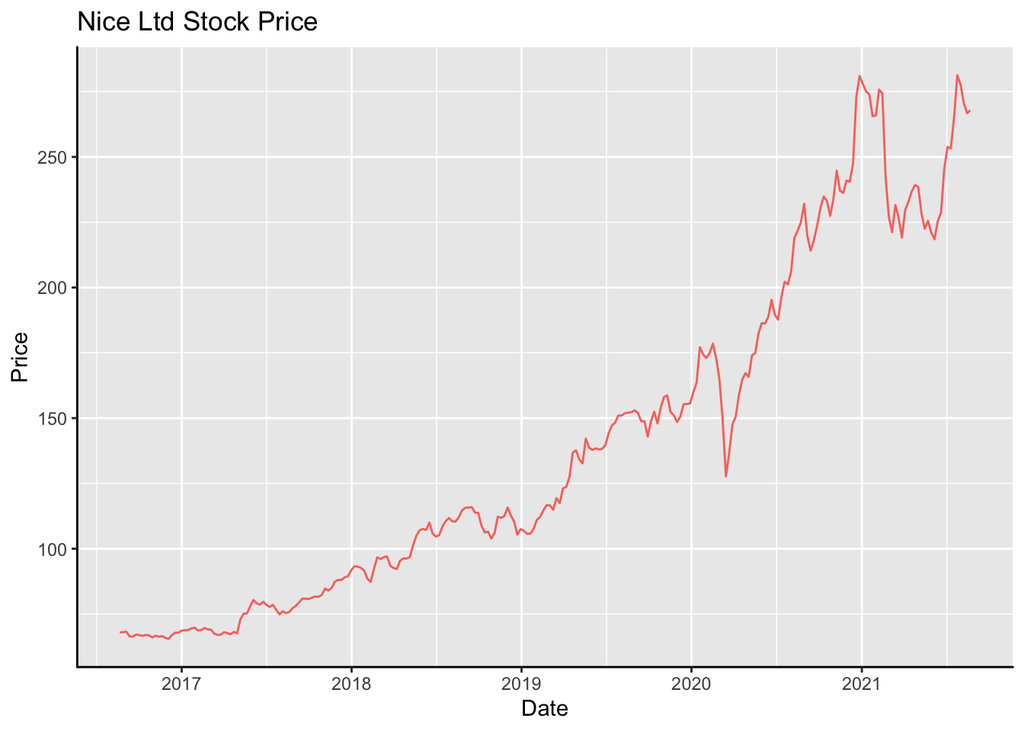

## **Alten**

[figure not shown]

**Company Sector:** Information Technology  
**Headquarters:** Paris  
**# of Employees:** 10,500  
**Website:** https://alten.fr/  
**Description:** Alten is high-technology consulting and engineering group. The group’s services are supplied to technical departments.  
**Market Cap (USD)** $5.4B

### **Trends**

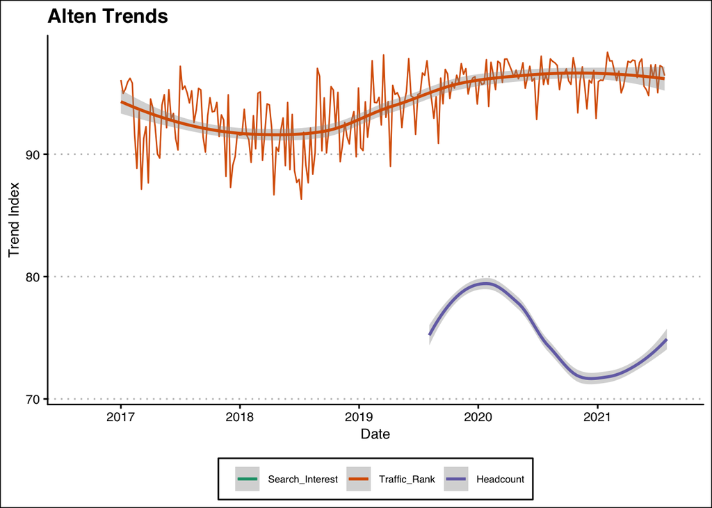

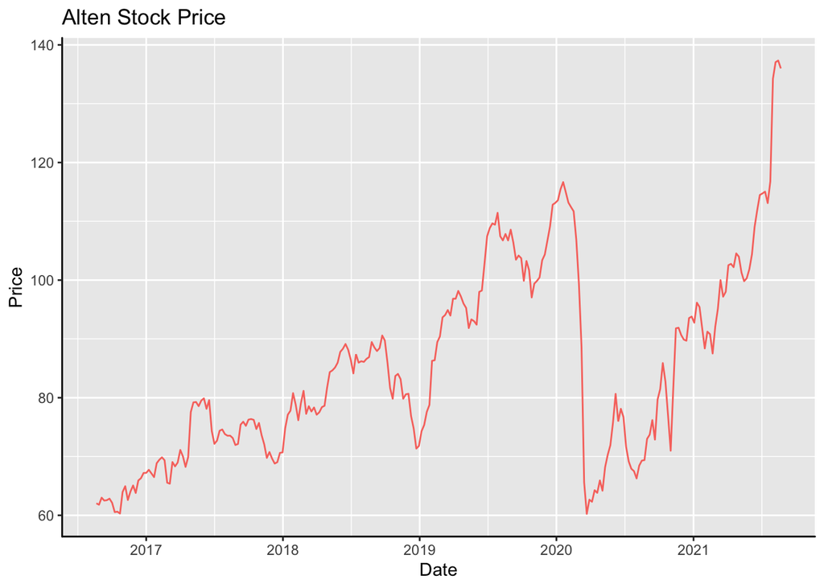

## **Embracer**

[figure not shown]

**Company Sector:** Gaming **Headquarters:** Sweden  
**# of Employees:** ~7,000  
**Website:** https://embracer.com/  
**Description:** Embracer Group is the parent company of businesses developing and publishing PC and console games for the global games market.  
**Market Cap (USD)** $11.3B

### **Trends**

[figure not shown]

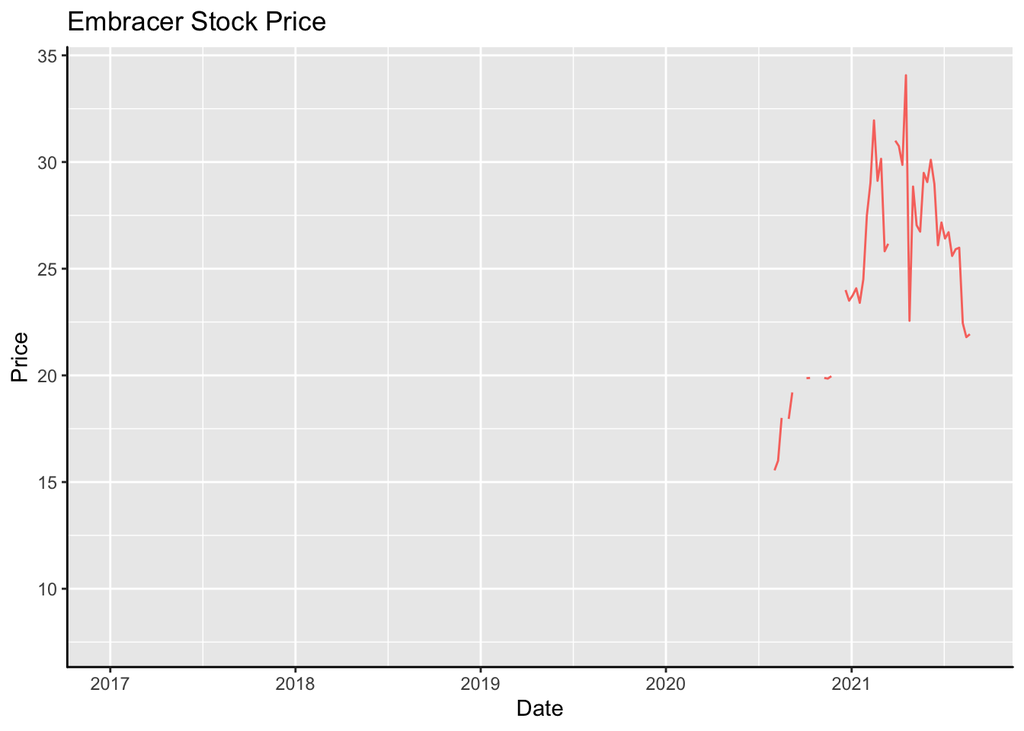

## **Stillfront**

[figure not shown]

**Company Sector:** Gaming **Headquarters:** Sweden  
**# of Employees:** ~1,000  
**Website:** https://stillfront.com/  
**Description:** Stillfront Group is an independent games creator and games publisher with a portfolio of high quality games.  
**Market Cap (USD)** $2.3B

### **Trends**

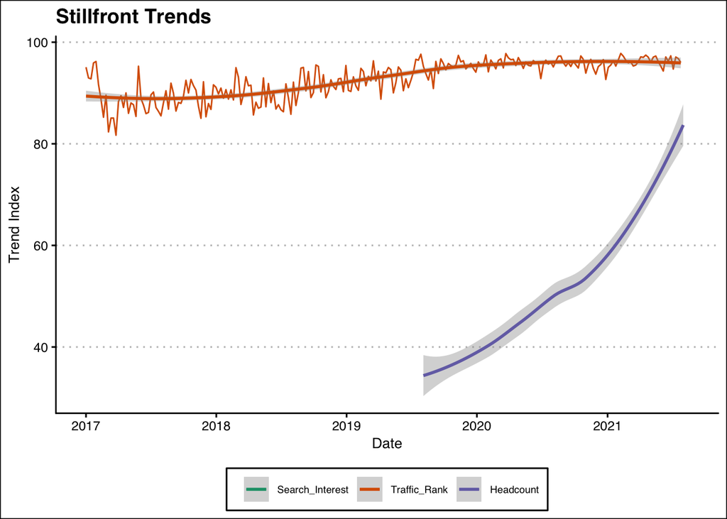

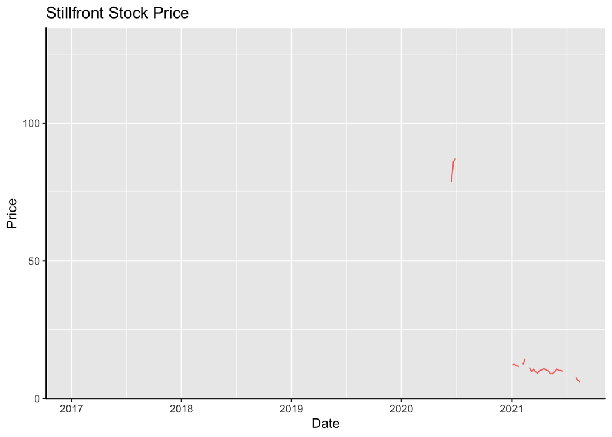

## **Essensys**

[figure not shown]

**Company Sector:** Coworking, SaaS, CRM  
**Headquarters:** London  
**# of Employees:** ~1,000  
**Website:** https://essensys.com/  
**Description:** essensys is a provider of mission-critical SaaS platforms and on-demand cloud services for the co-working industry. **Market Cap (USD)** $268M

### **Trends**

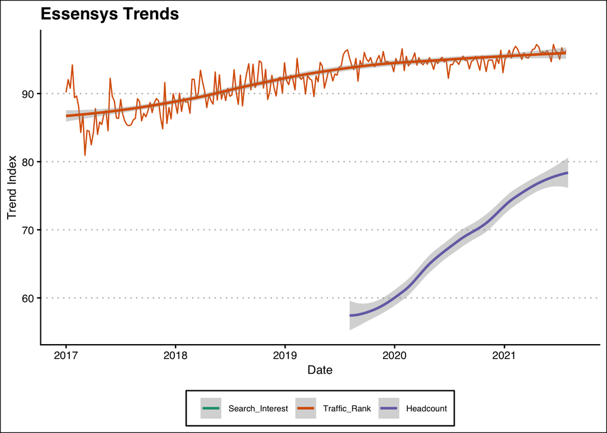

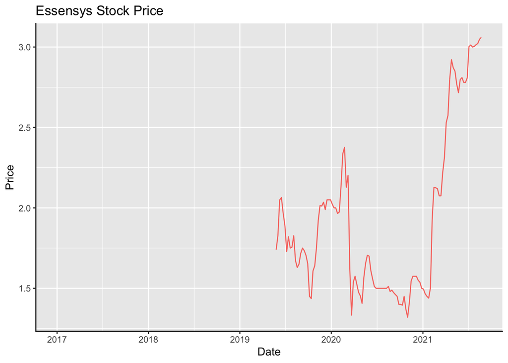

## **Kingdee**

[figure not shown]

**Company Sector:** E-Commerce, Enterprise Software **Headquarters:** Shenzhen  
**# of Employees:** 2,300  
**Website:** https://kingdee.com/  
**Description:** Kingdee offers management software, online management, consultancy, integration e-commerce server solutions, and informalization services.  
**Market Cap (USD)** $10.9B

### **Trends**

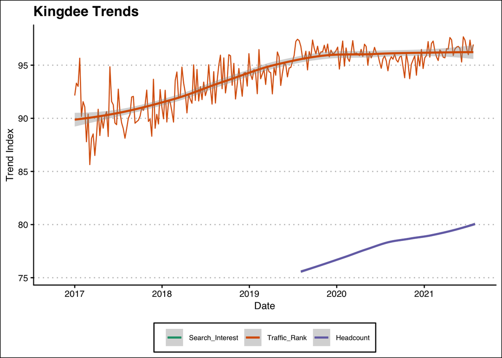

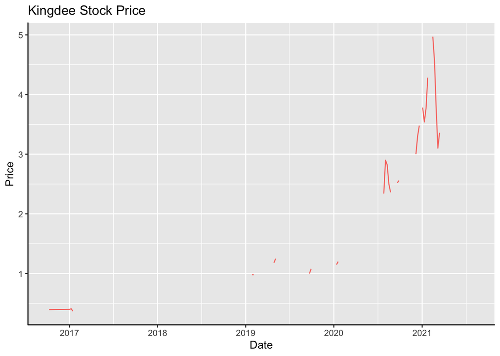

## **Kinaxis**

[figure not shown]

**Company Sector:** Enterprise Software, Analytics, Automotive  
**Headquarters:** Ottawa  
**# of Employees:** 1,157  
**Website:** https://kinaxis.com/  
**Description:** Kinaxis is a leading provider of cloud-based subscription software.  
**Market Cap (USD)** $3.97B

### **Trends**

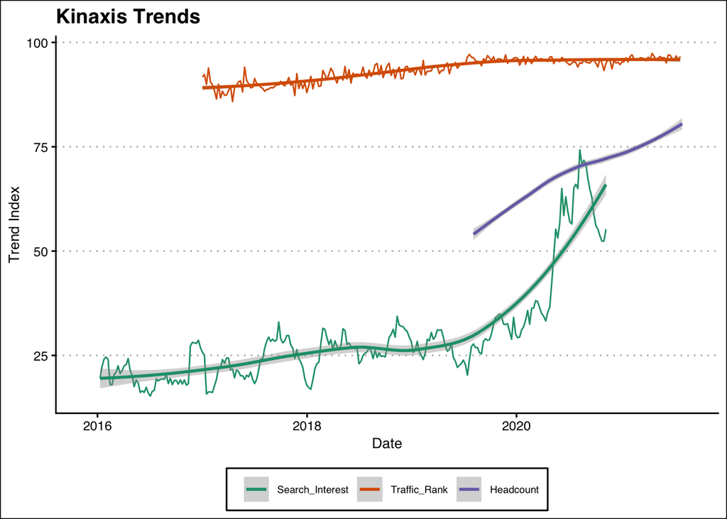

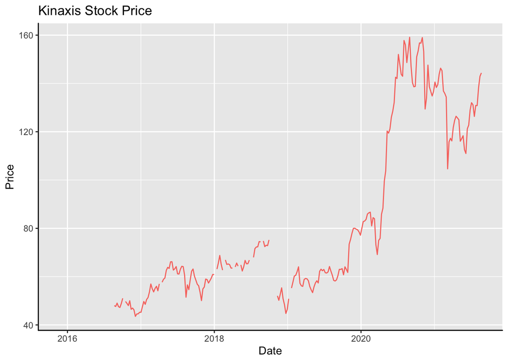